# Lab Work and Assignment 3 for Biom612 (Week 3) v3

Deanne Taylor, with some edits by Yuanchao Zhang

Jan 29th, 2018

# Starting Up

Packages to install this week:

- UsingR
- gtools
- lawstat
- moments

# Lab Updates

A series of “To Think About” questions are presented below. These are not to be passed in as homework problems. They are not graded.

The only required homework problems are below the words “Homework Assignment.”

The “To Think About” questions are only meant to test your own knowledge of the material and will be discussed in lab.

# Bernoulli Variable

The {1,0} sample space random variable was introduced last week, specifically for a coin toss. We call this kind of random variable a “Bernoulli variable” and it’s generated with a Bernoulli process: flipping a coin.

We can use the sample() function to generate a set of coin tosses using an approximation to the Bernoulli process. Let’s assume 0=tails, and 1=heads. We know that in a fair coin, a flip is independent, and not affected by the previous coin flip’s results. A fair coin’s sample space of {0,1} has equal probabilities of being sampled. That is, p=0.50 for each of heads or tails. Therefore, the random variable generated from the coin toss is “iid” – Independent and Identically Distributed.

```r
# Run this chunk several times to get a feel for what's going on.

n = 20  #Number of Bernoulli Trials
p = 0.5  #Probability of heads

bern_set <- sample(c(0, 1), size = n, replace = TRUE, prob = c(1 - p, p))
bern_set
```

```
##  [1] 1 0 1 0 0 1 0 0 0 0 1 1 1 0 0 0 0 0 1 1
```

```r
# What is the number of successes (heads) in this test?

ratio_successes <- sum(bern_set)/n
ratio_successes
```

```
## [1] 0.4
```

A little trick– if you don’t want your random variable to change every time you use it, there’s a function called ‘set.seed()’ that allows you to retrieve the earlier randomization result by setting a randomization parameter. You call it right before your randomization:

```r
set.seed(1234)
bern_set_ss <- sample(c(0, 1), size = n, replace = TRUE, prob = c(1 - p, p))
bern_set_ss
```

```
##  [1] 1 0 0 0 0 0 1 1 0 0 0 0 1 0 1 0 1 1 1 1
```

```r
ratio_successes_ss <- sum(bern_set_ss)/n
ratio_successes_ss
```

```
## [1] 0.45
```

The set.seed() only works for the code immediately executing after it, but it’s good to help retrieve and set results. If you re-sampled a random distribution after you ‘used’ set.seed() it would still randomly sample the data.

To Think About:

- What if you used replace=FALSE in sample? What does this mean?
- In Chunk 1, why is p set to c(1-p, p)?
- How would you use the functions above to generate a distribution?

# Binomial Coefficient

The binomial coefficient is “n choose k” or nCk or ${{n}\choose{k}}$, and is just a shorthand for a factorial expansion:

$${{n}\choose{k}} = \frac{n!}{k!(n-k)!}$$
A binomial coefficient equals the number of combinations of k items that can be selected from a set of n trials.

Another way of saying this is, how do we get k unordered outcomes from n possibilities?

We can easily explore the binomial coefficient with R’s choose() function/

```r
# Number of ways to get k objects in a n-member trial: choose(n,k)

choose(5, 2)
```

```
## [1] 10
```

To think about:

## Examples using the binomial coefficient

### Flipping a coin

If a coin is flipped 5 times then there will be ${{5}\choose{3}}=10$ (5C3) ways that three heads can show up in the 5 flips:

$${{5}\choose{3}}= \frac{5!}{3!(5-3)!} =10$$

```r
# binomial 5C3 calculation result:
choose(5, 3)
```

```
## [1] 10
```

```r
# permutations is a gtools package. ?permutations for help
x <- c(1, 0)
permtest5C3 <- permutations(n = 2, r = 5, v = x, repeats.allowed = TRUE)
permtest5C3
```

```
##       [,1] [,2] [,3] [,4] [,5]
##  [1,]    0    0    0    0    0
##  [2,]    0    0    0    0    1
##  [3,]    0    0    0    1    0
##  [4,]    0    0    0    1    1
##  [5,]    0    0    1    0    0
##  [6,]    0    0    1    0    1
##  [7,]    0    0    1    1    0
##  [8,]    0    0    1    1    1
##  [9,]    0    1    0    0    0
## [10,]    0    1    0    0    1
## [11,]    0    1    0    1    0
## [12,]    0    1    0    1    1
## [13,]    0    1    1    0    0
## [14,]    0    1    1    0    1
```

[output cut: 18 more lines]

```r
# sum up how many heads show up in each combination of permtest
permsums5C3 <- rowSums(permtest5C3)
permsums5C3
```

```
##  [1] 0 1 1 2 1 2 2 3 1 2 2 3 2 3 3 4 1 2 2 3 2 3 3 4 2 3 3 4 3 4 4 5
```

```r
# how many of these are equal to three?
length(which(permsums5C3 == 3))
```

```
## [1] 10
```

```r
# What are the permutations that satisify 5C3?
permtest5C3[which(permsums5C3 == 3), ]
```

```
##       [,1] [,2] [,3] [,4] [,5]
##  [1,]    0    0    1    1    1
##  [2,]    0    1    0    1    1
##  [3,]    0    1    1    0    1
##  [4,]    0    1    1    1    0
##  [5,]    1    0    0    1    1
##  [6,]    1    0    1    0    1
##  [7,]    1    0    1    1    0
##  [8,]    1    1    0    0    1
##  [9,]    1    1    0    1    0
## [10,]    1    1    1    0    0
```

However, we don’t have to limit the binomial coefficient to just two element sample spaces.

### Testing an 5-element sample set.

Imagine you have a 5-element sample space: {a, b, c, d, e}. To find out how many different subsets of 2 elements this space has:

$${{5}\choose{2}}= \frac{5!}{2!(5-2)!} = \frac{120}{12}=10$$

```r
# binomial 5C2 calculation result:
choose(5, 2)
```

```
## [1] 10
```

```r
# The combinations function is also in the gtools package. ?combinations for help

x <- c("a", "b", "c", "d", "e", "f")
permtest5C2 <- combinations(5, 2, letters[1:5], repeats.allowed = FALSE)
permtest5C2
```

```
##       [,1] [,2]
##  [1,] "a"  "b"
##  [2,] "a"  "c"
##  [3,] "a"  "d"
##  [4,] "a"  "e"
##  [5,] "b"  "c"
##  [6,] "b"  "d"
##  [7,] "b"  "e"
##  [8,] "c"  "d"
##  [9,] "c"  "e"
## [10,] "d"  "e"
```

```r
# For this example we use combinations() and not permutations() because
# combinations() will not return both (a,b) and (b,a), while permutations() will.
```

To think about:

- 5C3 and 5C2 both had a result of 10.
- Why couldn’t we use combinations() for our examples above for x=c(1,0) in Chunk 3?
- Why couldn’t we use permutations() instead of combinations in Chunk 4?

### Probability of observing k heads in n flips

Let’s calculate the probability of observing only two heads with four flips of a fair coin.

We start with the binomial coefficient:

$${{4}\choose{2}}= \frac{4!}{2!(4-2)!} = \frac{24}{4}=6$$

```r
# binomial 4C2 calculation result:
choose(4, 2)
```

```
## [1] 6
```

```r
x <- c(1, 0)

permtest4C2 <- permutations(n = 2, r = 4, v = x, repeats.allowed = TRUE)

permtest4C2
```

```
##       [,1] [,2] [,3] [,4]
##  [1,]    0    0    0    0
##  [2,]    0    0    0    1
##  [3,]    0    0    1    0
##  [4,]    0    0    1    1
##  [5,]    0    1    0    0
##  [6,]    0    1    0    1
##  [7,]    0    1    1    0
##  [8,]    0    1    1    1
##  [9,]    1    0    0    0
## [10,]    1    0    0    1
## [11,]    1    0    1    0
## [12,]    1    0    1    1
## [13,]    1    1    0    0
## [14,]    1    1    0    1
## [15,]    1    1    1    0
## [16,]    1    1    1    1
```

```r
# sum up how many heads show up in each combination of permtest

permsums4C2 <- rowSums(permtest4C2)
permsums4C2
```

```
##  [1] 0 1 1 2 1 2 2 3 1 2 2 3 2 3 3 4
```

```r
# how many of these configurations are equal to two?
length(which(permsums4C2 == 2))
```

```
## [1] 6
```

```r
# What are the permutations that satisify 4C2?
permtest4C2[which(permsums4C2 == 2), ]
```

```
##      [,1] [,2] [,3] [,4]
## [1,]    0    0    1    1
## [2,]    0    1    0    1
## [3,]    0    1    1    0
## [4,]    1    0    0    1
## [5,]    1    0    1    0
## [6,]    1    1    0    0
```

The full length of all outcomes of successes in four flips of a coin is 16, representing all different combinations of successes in four flips. See variable permsums4C2

For 4C2, two heads will show up 6 times, out of all 16 possible outcomes of four flips of a coin.

Therefore, we know that the probability of finding two heads in four flips of a coin is 6/16 or 3/8 or 0.375.

To think about:

- Run the following lines. Start with chnum=3. What does the plot represent? What is the significance of the values on the plot?

chnum<-3 choose_func<-choose(chnum,c(0:chnum)) chdist<-choose_func/sum(choose_func) plot(seq(from=0, to=chnum),chdist, type=“l”, ylim=c(0,.50))

- Increase chnum several times. What do you observe?
- From the help files, it says “Note that choose(n, k) is defined for all real numbers n and integer k” meaning that n can be a decimal number. What would something like 6.75 choose 2 mean?

# Binomial Distribution

We just went through the long way of calculating the probabilty of seeing two heads in a trial of four flips of a coin. There’s an easy way to go about this, using the binomial distribution equation. The binomial equation represents the probability of exactly x successes in n Bernoulli trials. Recall Bernoulli trials implies the sample space is {0,1}

See also https://en.wikipedia.org/wiki/Binomial_distribution

We can generate a binomial distribution using the binomial coefficient, with the number of trials n, k items, and the probability of success p.

Back to our example, the probability of getting exactly k successes in n Bernoulli trials is given by the probability mass function:

$$Pr(k;n,p) = {{n}\choose{k}} \cdot p^k \cdot (1-p)^{n-k}$$

```r
# Probability of seeing two heads in a trial of four flips of a coin. Note we
# have to give the probability of heads as 0.5, as this is a fair coin.

# Probability the long way:
length(which(permsums4C2 == 2))/length(permsums4C2)
```

```
## [1] 0.375
```

```r
# Probability using the binomial distribution function dnorm():
dbinom(x = 2, size = 4, prob = 0.5)  #Prob. for 4C2
```

```
## [1] 0.375
```

# Significance Tests and Confidence Intervals

Some of these examples follow along with Chapter 7, in *Using R* by John Verzani, available in our class course reserve as an e-book on CANVAS and is your assigned reading.

## Confidence intervals using simulation

Verzani 7.1: Simulating a data set and estimating confidence intervals

```r
pop = rep(0:1, c(10000 - 5600, 5600))
phat = mean(sample(pop, 100))
phat
```

```
## [1] 0.45
```

```r
res = c()
for (i in 1:1000) res[i] = mean(sample(pop, 100))
quantile(res, c(0.1, 0.9))  # 80% of the time
```

```
##  10%  90%
## 0.50 0.63
```

```r
quantile(res, c(0.05, 0.95))  # 90% of the time
```

```
##   5%  95%
## 0.48 0.64
```

```r
quantile(res, c(0.025, 0.975))  # 95% of the time
```

```
##  2.5% 97.5%
##  0.46  0.66
```

## Confidence intervals for a population proportion

We begin studying confidence intervals with a test we’ve explored last week: the one-sample test of proportion. Other coverage of confidence intervals will be covered below for each test under Significance Tests.

Verzani covers the CI for prop.test() in section 7.2.1 : Using prop.test() to find confidence intervals

### CI for proportions: Verzani example 7.2

```r
n = 1013
phat = 466/n
SE = sqrt(phat * (1 - phat)/n)

alpha = 0.05

zstar = -qnorm(alpha/2)
zstar  # nearly 2 if doing by hand
```

```
## [1] 1.959964
```

```r
c(phat - zstar * SE, phat + zstar * SE)  #phat +/- CI
```

```
## [1] 0.4293281 0.4907114
```

```r
phat + c(-1, 1) * zstar * SE
```

```
## [1] 0.4293281 0.4907114
```

```r
# See Verzani page 184-185

prop.test(466, 1013, conf.level = 0.95)
```

```
##
##  1-sample proportions test with continuity correction
##
## data:  466 out of 1013, null probability 0.5
## X-squared = 6.3179, df = 1, p-value = 0.01195
## alternative hypothesis: true p is not equal to 0.5
## 95 percent confidence interval:
##  0.4290475 0.4912989
## sample estimates:
##         p
## 0.4600197
```

### CI example on heavy smokers

This exercise is taken from Week 2 lab (prop.test), testing if a normally distributed second study of lung cancer has more heavy smokers than the number of heavy smokers in a previous study. Here, the normal distribution for a second trial is assumed where 30/200 patients out of that distribution are heavy smokers. We (arbitrarily) will define “heavy smokers” as the upper 10% of the previous study. The null hypothesis of no difference can be rejected if p < 0.05.

```r
hs = 30  # Second study number of heavy smokers
p0 = 0.1  # Previous study's heavy smoker proportion
n2 = 200  # Second study's number of patients

# no Yates correction, and alterative hypothesis is p>=p0
propresult <- prop.test(hs, n2, p = p0, correct = FALSE, alternative = "greater",
    conf.level = 0.95)

print(propresult)
```

```
##
##  1-sample proportions test without continuity correction
##
## data:  hs out of n2, null probability p0
## X-squared = 5.5556, df = 1, p-value = 0.009211
## alternative hypothesis: true p is greater than 0.1
## 95 percent confidence interval:
##  0.1131554 1.0000000
## sample estimates:
##    p
## 0.15
```

In “propresult”, we see that the “alternative hypothesis” would be that the true proportion p is greater than 0.10 from the previous study’s heavy smokers. Not a surprise, as that’s what we stipulated in the parameters in Chunk #10.

The p-value as Chunk 10 is written is about 0.01. The confidence interval of the second test’s modeled distribution values at 95% confidence level falls between about 0.113 and 1.0. That interval does not contain the previous study’s proportion value of 0.10, so therefore this value falls outside of that range.

```r
# using the binomial distribution (see class notes)
alpha <- 0.05

# Here we use rbinom to model how many times we get 'heads' on a fair coin if we
# trial by tossing the coin it 20 times, then repeat the trial 10 times. We can
# also think of this as the number of ‘successes’ in a trial with n observations,
# repeated m times.

# One trial is 20 tosses of a coin, then repeating for 10 trials:
n <- 20  #20 tosses of a coin (n=observations)
m <- 10  #10 times (m=size, number of trials)
p <- 0.5  #probability,expected value for fair coin toss

binomial_trials <- rbinom(m, n, p)

binomial_trials
```

```
##  [1] 11 11 10  7 10 10 11 10 12 12
```

```r
# Looking at the result will help it make sense to you. There are 10 results from
# m=10 trials. In each of the trials, there are up to n heads showing.

# divide by n to get proportion.
binomial_prop <- binomial_trials/n

binomial_prop
```

```
##  [1] 0.55 0.55 0.50 0.35 0.50 0.50 0.55 0.50 0.60 0.60
```

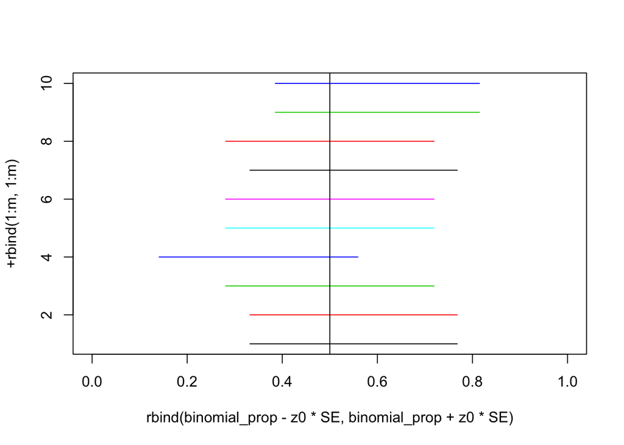

```r
# Note that the binomial_prop is the proportion of heads showing on each trial
# out of n=20.

# Standard Error:
SE = sqrt(binomial_prop * (1 - binomial_prop)/n)  #std error

z0 = qnorm(1 - alpha/2)  #two-tailed critical value (week 2)

matplot(rbind(binomial_prop - z0 * SE, binomial_prop + z0 * SE), +rbind(1:m, 1:m),
    type = "l", lty = 1, xlim = c(0, 1))
abline(v = p)  # draw line for p=0.5
```

## One sample Student’s t-test

One-sample tests of the mean are useful for limited types of tests but do get used once in a while, such as comparing a distribution of test results to a published experimental value.

```r
tcga_luad <- read.csv("TCGA_LUAD_clinical.csv", na.string = "NA", stringsAsFactors = FALSE,
    row.names = 1)

# Determine if the distribution from TCGA_LUAD could have been generated by a
# (random) process with a specific mean.

mu0 <- mean(tcga_luad$years_smoked, na.rm = TRUE)
t.test(tcga_luad$years_smoked, mu = mu0, alternative = "two.sided")
```

```
##
##  One Sample t-test
##
## data:  tcga_luad$years_smoked
## t = 0, df = 193, p-value = 1
## alternative hypothesis: true mean is not equal to 31.63402
## 95 percent confidence interval:
##  29.82802 33.44002
## sample estimates:
## mean of x
##  31.63402
```

```r
# Add something to the mean:

mu_add <- 2
t.test(tcga_luad$years_smoked, mu = mu0 + mu_add, alternative = "two.sided")
```

```
##
##  One Sample t-test
##
## data:  tcga_luad$years_smoked
## t = -2.1842, df = 193, p-value = 0.03015
## alternative hypothesis: true mean is not equal to 33.63402
## 95 percent confidence interval:
##  29.82802 33.44002
## sample estimates:
## mean of x
##  31.63402
```

## Confidence intervals for means (Verzani 7.3)

```r
zstar = 0.03/sqrt(0.57 * (1 - 0.57)/1000)
zstar
```

```
## [1] 1.916239
```

```r
alpha = 2 * pnorm(-zstar)
alpha
```

```
## [1] 0.05533472
```

```r
1 - alpha
```

```
## [1] 0.9446653
```

### Verzani 7.3: Confidence intervals for the population mean, $\mu$

```r
xbar = 66
s = 4
n = 30
alpha = 0.2
tstar = qt(1 - alpha/2, df = n - 1)
tstar
```

```
## [1] 1.311434
```

```r
SE = s/sqrt(n)
c(xbar - tstar * SE, xbar + tstar * SE)
```

```
## [1] 65.04226 66.95774
```

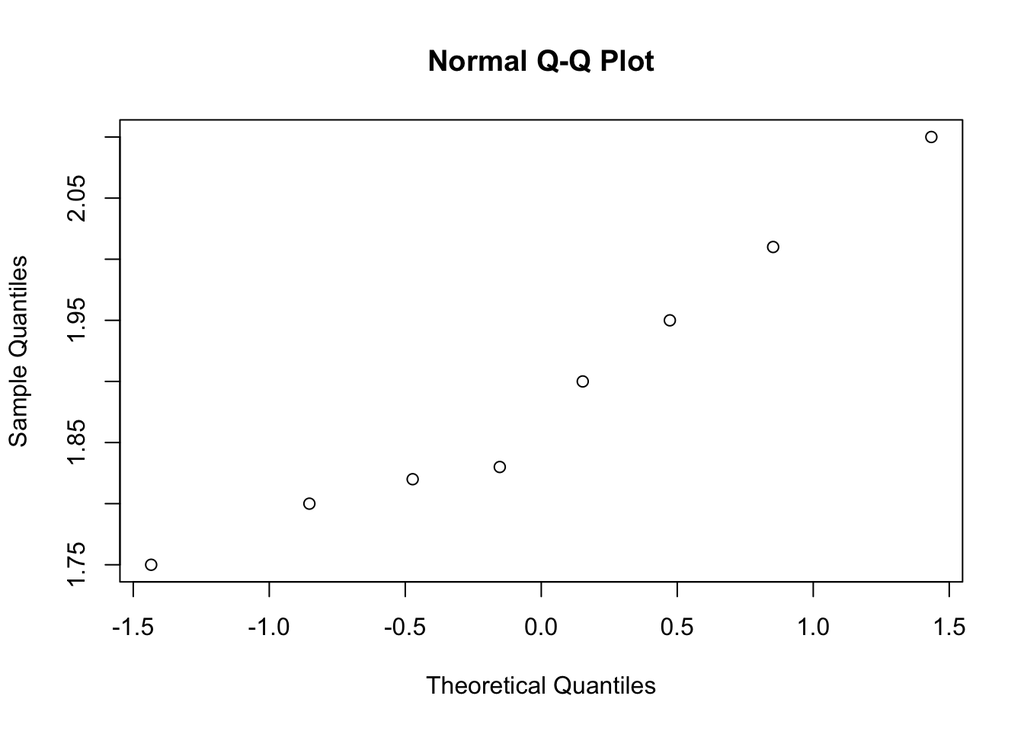

```r
ozs = c(1.95, 1.8, 2.1, 1.82, 1.75, 2.01, 1.83, 1.9)
qqnorm(ozs)  # approximately linear
```

```r
t.test(ozs, conf.level = 0.8)
```

```
##
##  One Sample t-test
##
## data:  ozs
## t = 45.253, df = 7, p-value = 6.724e-10
## alternative hypothesis: true mean is not equal to 0
## 80 percent confidence interval:
##  1.835749 1.954251
## sample estimates:
## mean of x
##     1.895
```

```r
x = c(175, 185, 170, 184, 175)
t.test(x, conf.level = 0.9, alt = "less")
```

```
##
##  One Sample t-test
##
## data:  x
## t = 61.567, df = 4, p-value = 1
## alternative hypothesis: true mean is less than 0
## 90 percent confidence interval:
##      -Inf 182.2278
## sample estimates:
## mean of x
##     177.8
```

## Wilcoxon Signed-Rank test

See also https://en.wikipedia.org/wiki/Wilcoxon_signed-rank_test

The Wilcoxon signed-rank statistic allows for an improvement on the confidence interval given by counting the number of data points above the median. Its usage is valid when the distribution is assumed to be symmetric about the median. See notes and Verzani section 7.6.2

How do we determine if a data set is symmetric around the median? Even if the mean and the median are very close to one another in value, there is no guarantee that the distribution is symmetric around the median.

There are two applications we can use to determine symmetry, like with testing for normality, we can check symmetry with a plot, or a statistical test.

Below is a way to use the function() function to generate your own code. We do this for symplot, a symmetry plot. Note that the “function(x)” call passes the value of x into the commands inside the function brackets.

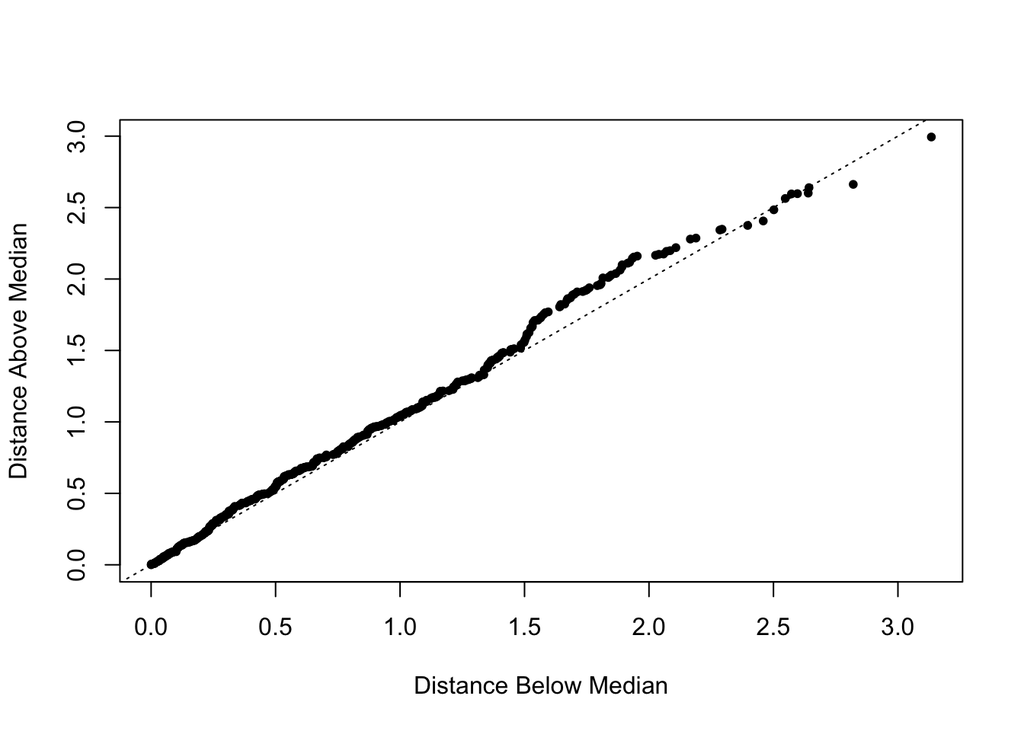

```r
# Code for symplot slightly adapted from Ross Ihaka. Ross, with Robert Gentleman,
# is one of the founders of the R statistical software system.

symplot = function(x) {
    x_finite <- x[which(is.finite(x))]
    n = length(x_finite)
    n2 = n%/%2
    sx = sort(x_finite)
    mx = median(x_finite)
    plot(mx - sx[1:n2], rev(sx)[1:n2] - mx, xlab = "Distance Below Median", ylab = "Distance Above Median",
        pch = 20)
    abline(a = 0, b = 1, lty = "dotted")
}

# example
randset <- rnorm(1000)
symplot(randset)
```

However, the downside is symmetry plots don’t do well when there are few points. For instance, run a symplot(rnorm(20)) and see how that performs. The normal distribution is obviously symmetric, but smaller samples from a distribituion will not approach the true distribution symmetry.

Another alterative is using a statistical test. There are several to choose from, but so far the only one I know of that is specifically designed for symmetry testing is the function symmetry.test() in the lawstats package. This performs well on smaller sets of points. The alternative hypothesis is that the distribution is asymmetric.

```r
# Note: symmetry.test takes longer to run as n gets larger.
n <- 100
myrnorm <- rnorm(n)
symmetry.test(myrnorm)
```

```
##
##  m-out-of-n bootstrap symmetry test by Miao, Gel, and Gastwirth
##  (2006)
##
## data:  myrnorm
## Test statistic = -1.8291, p-value = 0.126
## alternative hypothesis: the distribution is asymmetric.
## sample estimates:
## bootstrap optimal m
##                  35
```

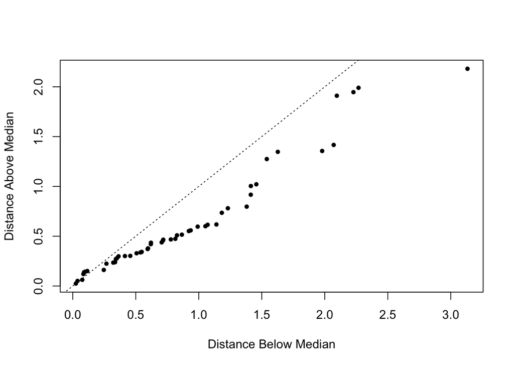

```r
symplot(myrnorm)
```

# Wilcoxon Signed-Rank test

This test assumes that the distribution being tested is symmetric about the median but does not have to be normally distributed.

```r
symmetry.test(tcga_luad$cigarettes_per_day)
```

```
##
##  m-out-of-n bootstrap symmetry test by Miao, Gel, and Gastwirth
##  (2006)
##
## data:  tcga_luad$cigarettes_per_day
## Test statistic = 1.7614, p-value = 0.124
## alternative hypothesis: the distribution is asymmetric.
## sample estimates:
## bootstrap optimal m
##                 316
```

```r
wilcox.test(tcga_luad$cigarettes_per_day, conf.int = TRUE, conf.level = 0.9)
```

```
##
##  Wilcoxon signed rank test with continuity correction
##
## data:  tcga_luad$cigarettes_per_day
## V = 63546, p-value < 2.2e-16
## alternative hypothesis: true location is not equal to 0
## 90 percent confidence interval:
##  1.986359 2.191818
## sample estimates:
## (pseudo)median
##       2.109589
```

# HOMEWORK Assignment 3

Feel free to work on this if you finish lab early but you should be working on your homework individually and preferably outside of lab.

Create a new R Markdown file for submitting this assignment. You should submit both your knit file in HTML and the original Rmd file to the Week 1 homework submission link in CANVAS. This homework is due 2/5/18 at 11:59 PM (evening).

For this assignment, please produce the markdown file and your knit file (pdf, html or doc), by submitting your files in the Assignment 2 link in the Week 2 Module.

## Question 1

## Question 2

## Question 3

## Question 4